# Cyclistic - Case Study 1

Saturnino

2022-12-01

This is an analysis on data from 2021-11 until 2022-10 on bike usage by Cyclistic users.

## Processing data

The datasets have been inspected and modified in excel prior to being loaded in R.

### Documentation of cleaning and manipulation before loading data in R

##### Added a “ride_length”, “day_of_week”, and “month” column to all .csv files.

- “ride_length” is equal to “ended_at” minus “started_at” column. (=”ended_at”-“started_at”)
- “day_of_week” created using the WEEKDAY function on column “started_at”. (=WEEKDAY(“started_at”,2)
- “month” created using the MONTH function on column “started_at”. (=MONTH(“started_at”)
- “ride_length” formatted as time, HH:MM:SS format.
- “day_of_week” and “month” formatted as number with no decimals.

##### Removing duplicates using the “Remove Duplicates” function in column “ride_id”.

##### Checking for errors and blanks using filters for all columns.

##### Not removing blanks or adding data to cells in columns “start_station_name”, “start_station_id”, “end_station_name”, “end_station_id”, “start_lat”, “start_lng”, “end_lat”, “end_lng”.

##### Data for 2021-11

- Removed 12 duplicates.
- Removed 53 entries where “ended_at” was before “started_at”, resulting in an error for “ride_length”. All errors are from the date 2021-11-07.
- Removed blank rows.

##### Data for 2021-12

- Clean, no duplicates, blank rows, or errors.

##### Data for 2022-01

- Clean, no duplicates, blank rows, or errors.

##### Data for 2022-02

- Clean, no duplicates, blank rows, or errors.

##### Data for 2022-03

- Removed 2 entries where “ended_at” was before “started_at”, resulting in an error for “ride_length”. Both errors are from the date 2022-03-05.
- No duplicates or blank rows.

##### Data for 2022-04

- Clean, no duplicates, blank rows, or errors.

##### Data for 2022-05

- Clean, no duplicates, blank rows, or errors.

##### Data for 2022-06

- Removed 1 duplicate.
- No blank rows or errors.

##### Data for 2022-07

- Removed 1 duplicate.
- Removed blank rows.
- No errors.

##### Data for 2022-08

- Clean, no duplicates, blank rows, or errors.

##### Data for 2022-09

- Clean, no duplicates, blank rows, or errors.

##### Data for 2022-10

- Removed 4 entries where “ended_at” was before “started_at”, resulting in an error for “ride_length”. Errors dated: 2022-10-03, 2022-10-13, 2022-10-21, 2022-10-24.
- No duplicates or blank rows.

### Loadint data into R

```r
#Loading libraries
library(tidyverse)
```

```r
library(ggplot2)
library(lubridate)
#Setting current folder to dataset location
setwd("F:/case_study_1_cyclistic")

#Loading .csv files
data_21_11 <- read.csv("202111-divvy-tripdata.csv")
data_21_12 <- read.csv("202112-divvy-tripdata.csv")
data_22_01 <- read.csv("202201-divvy-tripdata.csv")
data_22_02 <- read.csv("202202-divvy-tripdata.csv")
data_22_03 <- read.csv("202203-divvy-tripdata.csv")
data_22_04 <- read.csv("202204-divvy-tripdata.csv")
data_22_05 <- read.csv("202205-divvy-tripdata.csv")
data_22_06 <- read.csv("202206-divvy-tripdata.csv")
data_22_07 <- read.csv("202207-divvy-tripdata.csv")
data_22_08 <- read.csv("202208-divvy-tripdata.csv")
data_22_09 <- read.csv("202209-divvy-publictripdata.csv")
data_22_10 <- read.csv("202210-divvy-tripdata.csv")
```

### Data manipulation in R

##### After loading the data we combine it into one dataset “data_year”.

```r
#Combining all months into one dataset
data_year <- bind_rows(data_21_11, data_21_12, data_22_01, data_22_02, data_22_03, data_22_04, data_22_05, data_22_06, data_22_07, data_22_08, data_22_09, data_22_10)
```

##### Calculating ride length into seconds for easier calculation later, adding results into a new column “ride_length_2”.

```r
#Calculating ride length as seconds
data_year$ride_length_2 <- difftime(as_datetime(data_year$ended_at,format=("%d-%m-%Y %H:%M")), as_datetime(data_year$started_at,format=("%d-%m-%Y %H:%M")))
```

##### Changing the data type of “ride_length_2”.

```r
#Converting ride_length_2 as numeric value
data_year$ride_length_2<- as.numeric(as.character(data_year$ride_length_2))
```

##### Removing negatives in “ride_length_2” and creating a new version of the dataset “data_year_v2”.

```r
#Removing negatives missed in "ride_length_2" and creating a new version of the dataset
data_year_v2<-data_year[!(data_year$ride_length_2<0),]
```

##### Inspection of data before analysis.

```r
#Inspecting data before analysis
colnames(data_year_v2)
```

```
##  [1] "ride_id"            "rideable_type"      "day_of_week"
##  [4] "month"              "started_at"         "ended_at"
##  [7] "ride_length"        "start_station_name" "start_station_id"
## [10] "end_station_name"   "end_station_id"     "start_lat"
## [13] "start_lng"          "end_lat"            "end_lng"
## [16] "member_casual"      "ride_length_2"
```

```r
nrow(data_year_v2)
```

```
## [1] 5755581
```

```r
dim(data_year_v2)
```

```
## [1] 5755581      17
```

```r
head(data_year_v2)
```

```
##            ride_id rideable_type day_of_week month     started_at
## 1 7C00A93E10556E47 electric_bike           6    11 27-11-21 13:27
## 2 90854840DFD508BA electric_bike           6    11 27-11-21 13:38
## 3 0A7D10CDD144061C electric_bike           5    11 26-11-21 22:03
## 4 2F3BE33085BCFF02 electric_bike           6    11  27-11-21 9:56
## 5 D67B4781A19928D4 electric_bike           5    11 26-11-21 19:09
## 6 02F85C2C3C5F7D46 electric_bike           5    11 26-11-21 18:34
##         ended_at ride_length    start_station_name start_station_id
## 1 27-11-21 13:46     0:19:00
## 2 27-11-21 13:56     0:17:45
## 3 26-11-21 22:05     0:02:22
## 4 27-11-21 10:01     0:05:01
## 5 26-11-21 19:30     0:21:13
## 6 26-11-21 18:52     0:18:42 Michigan Ave & Oak St            13042
##   end_station_name end_station_id start_lat start_lng end_lat end_lng
## 1                                  41.93000 -87.72000   41.96  -87.73
## 2                                  41.96000 -87.70000   41.92  -87.70
## 3                                  41.96000 -87.70000   41.96  -87.70
## 4                                  41.94000 -87.79000   41.93  -87.79
## 5                                  41.90000 -87.63000   41.88  -87.62
## 6                                  41.90086 -87.62379   41.90  -87.63
##   member_casual ride_length_2
## 1        casual          1140
## 2        casual          1080
## 3        casual           120
## 4        casual           300
## 5        casual          1260
## 6        casual          1080
```

```r
str(data_year_v2)
```

```
## 'data.frame':    5755581 obs. of  17 variables:
##  $ ride_id           : chr  "7C00A93E10556E47" "90854840DFD508BA" "0A7D10CDD144061C" "2F3BE33085BCFF02" ...
##  $ rideable_type     : chr  "electric_bike" "electric_bike" "electric_bike" "electric_bike" ...
##  $ day_of_week       : int  6 6 5 6 5 5 6 6 6 6 ...
##  $ month             : int  11 11 11 11 11 11 11 11 11 11 ...
##  $ started_at        : chr  "27-11-21 13:27" "27-11-21 13:38" "26-11-21 22:03" "27-11-21 9:56" ...
##  $ ended_at          : chr  "27-11-21 13:46" "27-11-21 13:56" "26-11-21 22:05" "27-11-21 10:01" ...
##  $ ride_length       : chr  "0:19:00" "0:17:45" "0:02:22" "0:05:01" ...
##  $ start_station_name: chr  "" "" "" "" ...
##  $ start_station_id  : chr  "" "" "" "" ...
##  $ end_station_name  : chr  "" "" "" "" ...
##  $ end_station_id    : chr  "" "" "" "" ...
##  $ start_lat         : num  41.9 42 42 41.9 41.9 ...
##  $ start_lng         : num  -87.7 -87.7 -87.7 -87.8 -87.6 ...
##  $ end_lat           : num  42 41.9 42 41.9 41.9 ...
##  $ end_lng           : num  -87.7 -87.7 -87.7 -87.8 -87.6 ...
##  $ member_casual     : chr  "casual" "casual" "casual" "casual" ...
##  $ ride_length_2     : num  1140 1080 120 300 1260 1080 360 60 300 540 ...
```

```r
summary(data_year_v2)
```

```
##    ride_id          rideable_type       day_of_week        month
##  Length:5755581     Length:5755581     Min.   :1.000   Min.   : 1.000
##  Class :character   Class :character   1st Qu.:2.000   1st Qu.: 5.000
##  Mode  :character   Mode  :character   Median :4.000   Median : 7.000
##                                        Mean   :4.064   Mean   : 7.183
##                                        3rd Qu.:6.000   3rd Qu.: 9.000
##                                        Max.   :7.000   Max.   :12.000
##
##   started_at          ended_at         ride_length        start_station_name
##  Length:5755581     Length:5755581     Length:5755581     Length:5755581
##  Class :character   Class :character   Class :character   Class :character
##  Mode  :character   Mode  :character   Mode  :character   Mode  :character
##
##
##
##
##  start_station_id   end_station_name   end_station_id       start_lat
##  Length:5755581     Length:5755581     Length:5755581     Min.   :41.64
##  Class :character   Class :character   Class :character   1st Qu.:41.88
##  Mode  :character   Mode  :character   Mode  :character   Median :41.90
##                                                           Mean   :41.90
##                                                           3rd Qu.:41.93
##                                                           Max.   :45.64
##
##    start_lng         end_lat         end_lng       member_casual
##  Min.   :-87.84   Min.   :41.39   Min.   :-88.97   Length:5755581
##  1st Qu.:-87.66   1st Qu.:41.88   1st Qu.:-87.66   Class :character
##  Median :-87.64   Median :41.90   Median :-87.64   Mode  :character
##  Mean   :-87.65   Mean   :41.90   Mean   :-87.65
##  3rd Qu.:-87.63   3rd Qu.:41.93   3rd Qu.:-87.63
##  Max.   :-73.80   Max.   :42.37   Max.   :-87.30
##                   NA's   :5835    NA's   :5835
##  ride_length_2
##  Min.   :      0
##  1st Qu.:    360
##  Median :    600
##  Mean   :   1167
##  3rd Qu.:   1140
##  Max.   :2483220
##
```

## Data analysis

##### Descriptive analysis on ride length.

```r
#Descriptive analysis on ride length
seconds_to_period(mean(data_year_v2$ride_length_2))
```

```
## [1] "19M 26.5704887134755S"
```

```r
seconds_to_period(median(data_year_v2$ride_length_2))
```

```
## [1] "10M 0S"
```

```r
seconds_to_period(max(data_year_v2$ride_length_2))
```

```
## [1] "28d 17H 47M 0S"
```

```r
seconds_to_period(min(data_year_v2$ride_length_2))
```

```
## [1] "0S"
```

##### Comparing member and casual ride lengths.

```r
#Comparing member and casual
aggregate(data_year_v2$ride_length_2 ~ data_year_v2$member_casual, FUN = mean)
```

```
##   data_year_v2$member_casual data_year_v2$ride_length_2
## 1                     casual                  1750.3264
## 2                     member                   762.8902
```

```r
aggregate(data_year_v2$ride_length_2 ~ data_year_v2$member_casual, FUN = median)
```

```
##   data_year_v2$member_casual data_year_v2$ride_length_2
## 1                     casual                        780
## 2                     member                        540
```

```r
aggregate(data_year_v2$ride_length_2 ~ data_year_v2$member_casual, FUN = max)
```

```
##   data_year_v2$member_casual data_year_v2$ride_length_2
## 1                     casual                    2483220
## 2                     member                      93600
```

```r
aggregate(data_year_v2$ride_length_2 ~ data_year_v2$member_casual, FUN = min)
```

```
##   data_year_v2$member_casual data_year_v2$ride_length_2
## 1                     casual                          0
## 2                     member                          0
```

##### Comparing member and casual ride lengths by weekday.

```r
#Comparing by day
aggregate(data_year_v2$ride_length_2 ~ data_year_v2$member_casual + data_year_v2$day_of_week, FUN = mean)
```

```
##    data_year_v2$member_casual data_year_v2$day_of_week
## 1                      casual                        1
## 2                      member                        1
## 3                      casual                        2
## 4                      member                        2
## 5                      casual                        3
## 6                      member                        3
## 7                      casual                        4
## 8                      member                        4
## 9                      casual                        5
## 10                     member                        5
## 11                     casual                        6
## 12                     member                        6
## 13                     casual                        7
## 14                     member                        7
##    data_year_v2$ride_length_2
## 1                   1757.5667
## 2                    737.6668
## 3                   1561.1924
## 4                    728.1237
## 5                   1494.4820
## 6                    724.8107
## 7                   1528.2594
## 8                    734.8879
## 9                   1674.3503
## 10                   748.7318
## 11                  1958.0775
## 12                   850.9187
## 13                  2031.1434
## 14                   844.7286
```

```r
aggregate(data_year_v2$ride_length_2 ~ data_year_v2$member_casual + data_year_v2$day_of_week, FUN = median)
```

```
##    data_year_v2$member_casual data_year_v2$day_of_week
## 1                      casual                        1
## 2                      member                        1
## 3                      casual                        2
## 4                      member                        2
## 5                      casual                        3
## 6                      member                        3
## 7                      casual                        4
## 8                      member                        4
## 9                      casual                        5
## 10                     member                        5
## 11                     casual                        6
## 12                     member                        6
## 13                     casual                        7
## 14                     member                        7
##    data_year_v2$ride_length_2
## 1                         780
## 2                         480
## 3                         720
## 4                         480
## 5                         720
## 6                         540
## 7                         720
## 8                         540
## 9                         780
## 10                        540
## 11                        900
## 12                        600
## 13                        900
## 14                        600
```

##### Comparing member and casual ride lengths by month.

```r
#Comparing by month
aggregate(data_year_v2$ride_length_2 ~ data_year_v2$member_casual + data_year_v2$month, FUN = mean)
```

```
##    data_year_v2$member_casual data_year_v2$month data_year_v2$ride_length_2
## 1                      casual                  1                  1822.3445
## 2                      member                  1                   718.9612
## 3                      casual                  2                  1602.5233
## 4                      member                  2                   684.3413
## 5                      casual                  3                  1957.4573
## 6                      member                  3                   717.5056
## 7                      casual                  4                  1772.0302
## 8                      member                  4                   689.4765
## 9                      casual                  5                  1852.2608
## 10                     member                  5                   802.0482
## 11                     casual                  6                  1926.0165
## 12                     member                  6                   839.9418
## 13                     casual                  7                  1756.6785
## 14                     member                  7                   823.1304
## 15                     casual                  8                  1758.5965
## 16                     member                  8                   803.0934
## 17                     casual                  9                  1679.1286
## 18                     member                  9                   778.5838
## 19                     casual                 10                  1583.4157
## 20                     member                 10                   717.4989
## 21                     casual                 11                  1387.9653
## 22                     member                 11                   678.6018
## 23                     casual                 12                  1409.6696
## 24                     member                 12                   660.2750
```

```r
aggregate(data_year_v2$ride_length_2 ~ data_year_v2$member_casual + data_year_v2$month, FUN = median)
```

```
##    data_year_v2$member_casual data_year_v2$month data_year_v2$ride_length_2
## 1                      casual                  1                        600
## 2                      member                  1                        480
## 3                      casual                  2                        660
## 4                      member                  2                        480
## 5                      casual                  3                        840
## 6                      member                  3                        480
## 7                      casual                  4                        840
## 8                      member                  4                        480
## 9                      casual                  5                        900
## 10                     member                  5                        540
## 11                     casual                  6                        840
## 12                     member                  6                        600
## 13                     casual                  7                        840
## 14                     member                  7                        600
## 15                     casual                  8                        780
## 16                     member                  8                        600
## 17                     casual                  9                        720
## 18                     member                  9                        540
## 19                     casual                 10                        660
## 20                     member                 10                        480
## 21                     casual                 11                        660
## 22                     member                 11                        480
## 23                     casual                 12                        660
## 24                     member                 12                        480
```

##### Member and casual use of rideable types.

```r
#Rideable types compared
data_year_v2 %>% count(rideable_type, member_casual)
```

```
##   rideable_type member_casual       n
## 1  classic_bike        casual  897412
## 2  classic_bike        member 1740488
## 3   docked_bike        casual  182200
## 4 electric_bike        casual 1273365
## 5 electric_bike        member 1662116
```

##### Comparing member and casual ride counts and ride lengths by day.

```r
#Ridership by day and membership
data_year_v2 %>%
  mutate(weekday=wday(started_at,label=TRUE)) %>%
  group_by(member_casual,weekday) %>%
  summarise(num_of_rides=n(), average_duration=seconds_to_period(mean(ride_length_2)), median_ride_length=seconds_to_period(median(ride_length_2))) %>%
  arrange(member_casual, weekday)
```

```
## # A tibble: 14 × 5
## # Groups:   member_casual [2]
##    member_casual weekday num_of_rides average_duration      median_ride_length
##    <chr>         <ord>          <int> <Period>              <Period>
##  1 casual        Sun           333516 28M 19.8616558126148S 13M 0S
##  2 casual        Mon           354590 30M 12.0001692095095S 14M 0S
##  3 casual        Tue           350987 28M 48.9553174334092S 13M 0S
##  4 casual        Wed           338044 29M 21.9983197453587S 13M 0S
##  5 casual        Thu           323377 29M 53.2783716838242S 13M 0S
##  6 casual        Fri           314708 29M 3.26035563125174S 13M 0S
##  7 casual        Sat           337755 28M 31.3967224763514S 13M 0S
##  8 member        Sun           501161 12M 42.9485933662038S 9M 0S
##  9 member        Mon           485336 12M 49.9159757363972S 9M 0S
## 10 member        Tue           485685 12M 44.7114487785293S 9M 0S
## 11 member        Wed           490445 12M 39.2721711914689S 9M 0S
## 12 member        Thu           470914 12M 43.5330442501178S 9M 0S
## 13 member        Fri           481286 12M 32.088404815432S  9M 0S
## 14 member        Sat           487777 12M 47.701265127302S  9M 0S
```

##### Comparing member and casual ride counts and ride lengths by month.

```r
#Ridership by month and membership
data_year_v2 %>%
  group_by(member_casual,month) %>%
  summarise(num_of_rides=n(), average_duration=seconds_to_period(mean(ride_length_2)), median_ride_length=seconds_to_period(median(ride_length_2))) %>%
  arrange(member_casual, month)
```

```
## # A tibble: 24 × 5
## # Groups:   member_casual [2]
##    member_casual month num_of_rides average_duration      median_ride_length
##    <chr>         <int>        <int> <Period>              <Period>
##  1 casual            1        18520 30M 22.3444924406047S 10M 0S
##  2 casual            2        21416 26M 42.5233470302578S 11M 0S
##  3 casual            3        89880 32M 37.4572763684912S 14M 0S
##  4 casual            4       126417 29M 32.0301858136168S 14M 0S
##  5 casual            5       280415 30M 52.2607563789384S 15M 0S
##  6 casual            6       369045 32M 6.01650205259511S 14M 0S
##  7 casual            7       406047 29M 16.6785125859813S 14M 0S
##  8 casual            8       358919 29M 18.5965078471743S 13M 0S
##  9 casual            9       296696 27M 59.1286030145327S 12M 0S
## 10 casual           10       208988 26M 23.4156985090056S 11M 0S
## # … with 14 more rows
```

##### Visual comparing member and casual ride counts by day.

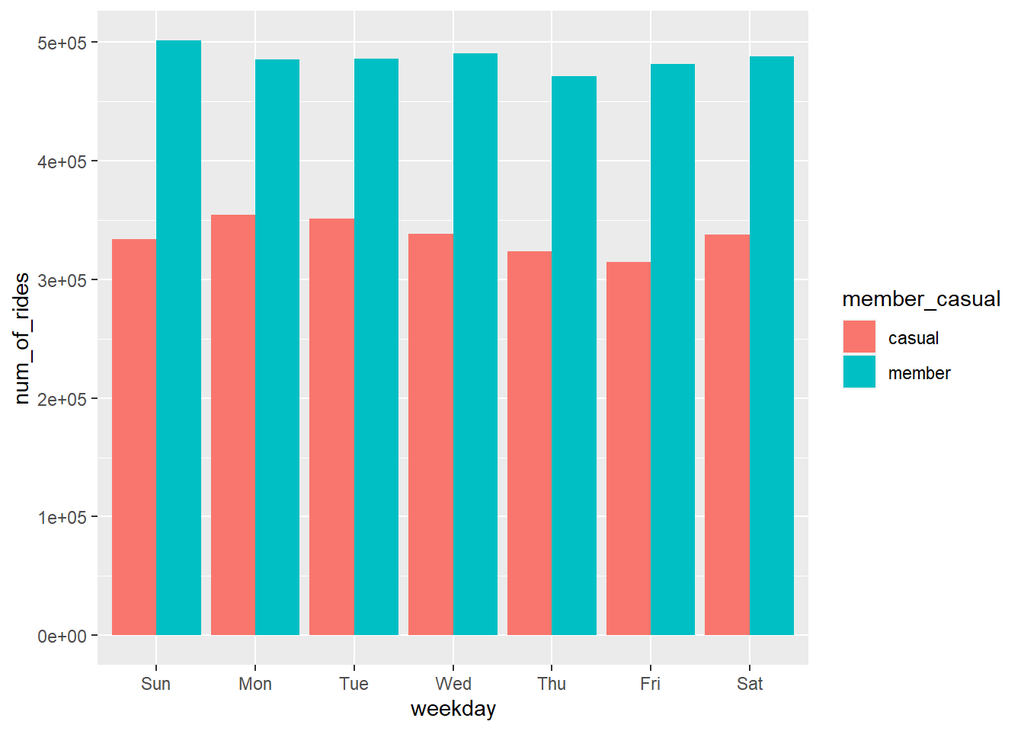

```r
#Visual for ridership by day
data_year_v2 %>%
  mutate(weekday=wday(started_at,label=TRUE)) %>%
  group_by(member_casual,weekday) %>%
  summarise(num_of_rides=n()) %>%
  arrange(member_casual, weekday) %>%
  ggplot(aes(x = weekday, y = num_of_rides, fill = member_casual)) +
  geom_col(position = "dodge")
```

##### Visual comparing member and casual ride counts by month.

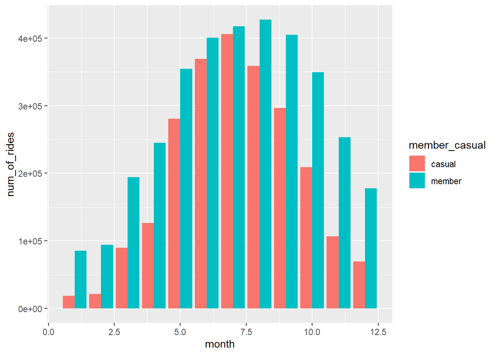

```r
#visual for ridership by month
data_year_v2 %>%
  group_by(member_casual,month) %>%
  summarise(num_of_rides=n()) %>%
  arrange(member_casual, month) %>%
  ggplot(aes(x = month, y = num_of_rides, fill = member_casual)) +
  geom_col(position = "dodge")
```

##### Visual comparing member and casual daily ride length averages.

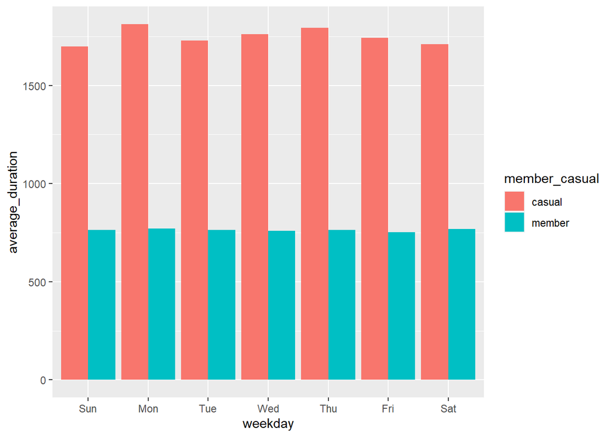

```r
#Visual for ridership day averages
data_year_v2 %>%
  mutate(weekday=wday(started_at,label=TRUE)) %>%
  group_by(member_casual,weekday) %>%
  summarise(num_of_rides=n(), average_duration=mean(ride_length_2)) %>%
  arrange(member_casual, weekday) %>%
  ggplot(aes(x = weekday, y = average_duration, fill = member_casual)) +
  geom_col(position = "dodge")
```

##### Visual comparing member and casual monthly ride length averages.

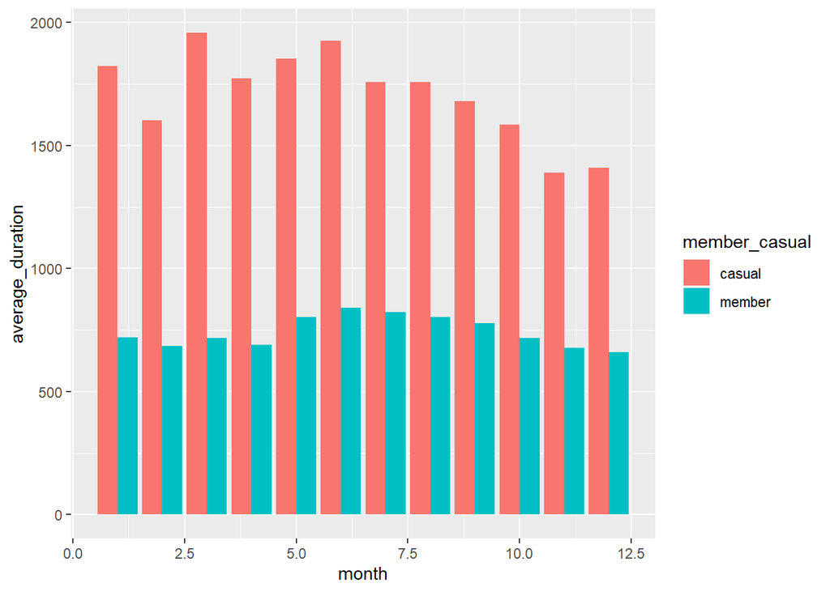

```r
#Visual for ridership month averages
data_year_v2 %>%
  group_by(member_casual,month) %>%
  summarise(num_of_rides=n(), average_duration=mean(ride_length_2)) %>%
  arrange(member_casual, month) %>%
  ggplot(aes(x = month, y = average_duration, fill = member_casual)) +
  geom_col(position = "dodge")
```

##### Visual comparing member and casual daily ride medians.

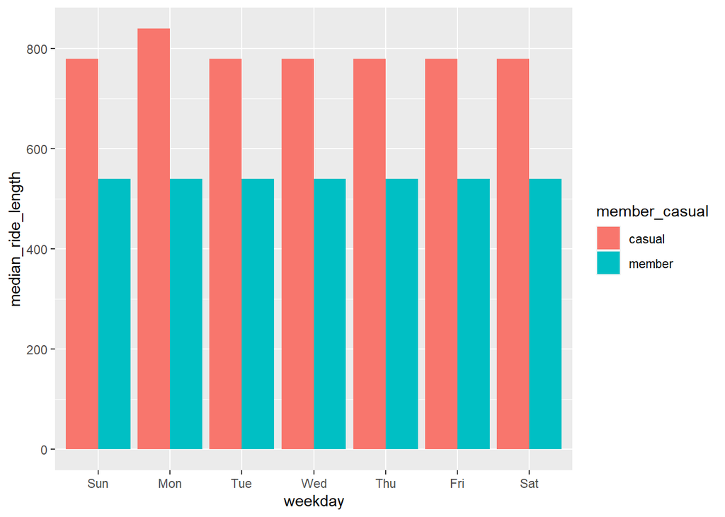

```r
#Visual for ridership day medians
data_year_v2 %>%
  mutate(weekday=wday(started_at,label=TRUE)) %>%
  group_by(member_casual,weekday) %>%
  summarise(num_of_rides=n(), median_ride_length=median(ride_length_2)) %>%
  arrange(member_casual, weekday) %>%
  ggplot(aes(x = weekday, y = median_ride_length, fill = member_casual)) +
  geom_col(position = "dodge")
```

##### Visual comparing member and casual monthly ride medians.

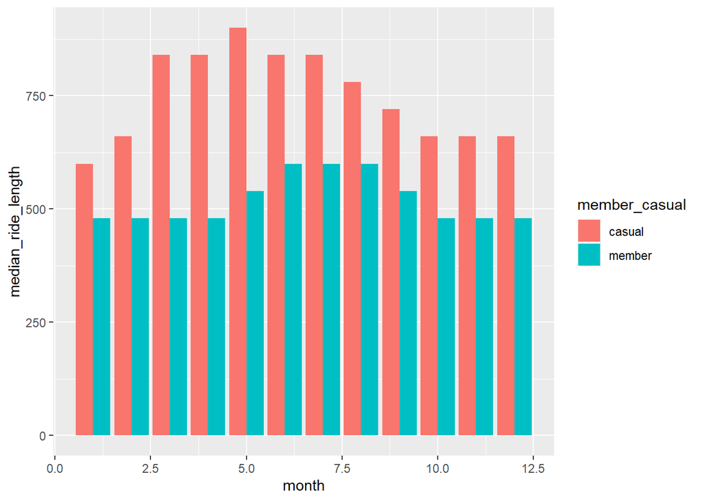

```r
#Visual for ridership month medians
data_year_v2 %>%
  group_by(member_casual,month) %>%
  summarise(num_of_rides=n(), median_ride_length=median(ride_length_2)) %>%
  arrange(member_casual, month) %>%
  ggplot(aes(x = month, y = median_ride_length, fill = member_casual)) +
  geom_col(position = "dodge")
```

## Exporting data

##### Exporting data for further analysis and visualization.

```r
#.csv data for export
daily_avg_med<-data_year_v2 %>%
  mutate(weekday=wday(started_at,label=TRUE)) %>%
  group_by(member_casual,weekday) %>%
  summarise(num_of_rides=n(), average_duration=seconds_to_period(mean(ride_length_2)), median_ride_length=seconds_to_period(median(ride_length_2))) %>%
  arrange(member_casual, weekday)
write.csv(daily_avg_med, file="daily_avg_med.csv")

monthly_avg_med<-data_year_v2 %>%
  group_by(member_casual,month) %>%
  summarise(num_of_rides=n(), average_duration=seconds_to_period(mean(ride_length_2)), median_ride_length=seconds_to_period(median(ride_length_2))) %>%
  arrange(member_casual, month)
write.csv(monthly_avg_med, file="monthly_avg_med.csv")

rideable_comp<-data_year_v2 %>% count(rideable_type, member_casual)
write.csv(rideable_comp, file="rideable_comp.csv")
```